# Rafael Nadal Model - Model Fit

En el presente documento analizaremos los partidos de Nadal en busca de patrones que nos permitan predecir el resultado de su proximo partido.

Arrancamos con un setup del environment.

```r
# install.packages("keras")
# install.packages("neuralnet")


pacman::p_load(pacman, tidyverse, rio, magrittr, lubridate,
               boot, caret)


options(scipen = 999)
```

Importamos la data previamente trabajada y seleccionamos las variables a utilizar.

```r
matches_nadal_ok <- import("Output/matches_nadal_ok.Rdata") %>%
  as_tibble()

glimpse(matches_nadal_ok)
```

```
Rows: 1,123
Columns: 44
$ Location               <fct> Doha, Doha, Doha, Auckland, Melbourne, Melbourne, Melbourne, Melbourne, Buen~
$ Tournament             <chr> "Qatar Exxon Mobil Open", "Qatar Exxon Mobil Open", "Qatar Exxon Mobil Open"~
$ Date                   <date> 2005-01-04, 2005-01-05, 2005-01-06, 2005-01-11, 2005-01-18, 2005-01-20, 200~
$ Series                 <fct> International, International, International, International, Grand Slam, Gran~
$ Court                  <fct> Outdoor, Outdoor, Outdoor, Outdoor, Outdoor, Outdoor, Outdoor, Outdoor, Outd~
$ Surface                <fct> Hard, Hard, Hard, Hard, Hard, Hard, Hard, Hard, Clay, Clay, Clay, Clay, Clay~
$ Round                  <fct> 1st Round, 2nd Round, Quarterfinals, 1st Round, 1st Round, 2nd Round, 3rd Ro~
$ BestOf                 <fct> 3, 3, 3, 3, 5, 5, 5, 5, 3, 3, 3, 3, 3, 3, 3, 3, 3, 3, 3, 3, 3, 3, 3, 3, 3, 3~
$ W1                     <dbl> 6, 6, 6, 6, 6, 6, 6, 7, 7, 6, 0, 7, 6, 6, 2, 6, 6, 7, 7, 6, 6, 6, 6, 6, 6, 6~
$ L1                     <dbl> 3, 2, 2, 3, 0, 1, 1, 5, 6, 1, 6, 6, 3, 2, 6, 0, 4, 6, 5, 4, 1, 4, 2, 4, 2, 4~
$ W2                     <dbl> 7, 6, 6, NA, 6, 4, 6, 3, 6, 6, 6, 6, 6, 6, 6, 6, 6, 6, 6, 6, 6, 7, 6, 6, 6, ~
$ L2                     <dbl> 6, 4, 7, NA, 4, 6, 1, 6, 3, 3, 0, 3, 3, 7, 2, 7, 4, 2, 3, 1, 0, 6, 2, 7, 4, ~
$ W3                     <dbl> NA, NA, 6, NA, 6, 4, 6, 1, NA, NA, 6, NA, NA, 6, 6, 6, NA, NA, NA, NA, NA, N~
```

[output cut: 31 more lines]

```r
# SEPARO VARIABLES A UTILIZAR

variables <- c("Location", "Series", "Court", "Surface", "Date",
               "Round", "BestOf", "RankNadal", "RankRival",
               "PartidosUlt6Meses", "PartidosUlt3Meses", "PartidosUltMes",
               "WRUlt6Meses", "WRUlt3Meses", "WRUltMes",
               "PartidosRivalUlt6Meses", "PartidosRivalUlt3Meses",
               "PartidosRivalUltMes", "WRRivalUlt6Meses", "WRRivalUlt3Meses",
               "WRRivalUltMes", "SetsGanadosUltPartido", "SetsPerdidosUltPartido",
               "ResultUltPartido", "RoundUltPartido", "H2HPartidos", "H2HGanados",
               "Result")

df_matches <- matches_nadal_ok %>%
  select(all_of(variables))

glimpse(df_matches)
```

```
Rows: 1,123
Columns: 28
$ Location               <fct> Doha, Doha, Doha, Auckland, Melbourne, Melbourne, Melbourne, Melbourne, Buen~
$ Series                 <fct> International, International, International, International, Grand Slam, Gran~
$ Court                  <fct> Outdoor, Outdoor, Outdoor, Outdoor, Outdoor, Outdoor, Outdoor, Outdoor, Outd~
$ Surface                <fct> Hard, Hard, Hard, Hard, Hard, Hard, Hard, Hard, Clay, Clay, Clay, Clay, Clay~
$ Date                   <date> 2005-01-04, 2005-01-05, 2005-01-06, 2005-01-11, 2005-01-18, 2005-01-20, 200~
$ Round                  <fct> 1st Round, 2nd Round, Quarterfinals, 1st Round, 1st Round, 2nd Round, 3rd Ro~
$ BestOf                 <fct> 3, 3, 3, 3, 5, 5, 5, 5, 3, 3, 3, 3, 3, 3, 3, 3, 3, 3, 3, 3, 3, 3, 3, 3, 3, 3~
$ RankNadal              <dbl> 51, 51, 51, 50, 56, 56, 56, 56, 48, 48, 48, 48, 48, 48, 48, 48, 39, 39, 39, ~
$ RankRival              <dbl> 16, 36, 22, 20, 65, 15, 283, 3, 61, 66, 8, 55, 86, 60, 56, 61, 81, 77, 12, 7~
$ PartidosUlt6Meses      <int> 1, 2, 3, 4, 5, 6, 7, 8, 9, 10, 11, 12, 14, 14, 15, 16, 17, 18, 19, 20, 21, 2~
$ PartidosUlt3Meses      <int> 1, 2, 3, 4, 5, 6, 7, 8, 9, 10, 11, 12, 14, 14, 15, 16, 17, 18, 19, 20, 21, 2~
$ PartidosUltMes         <int> 1, 2, 3, 4, 5, 6, 7, 8, 6, 6, 7, 8, 9, 9, 9, 10, 10, 10, 11, 12, 13, 4, 4, 3~
$ WRUlt6Meses            <dbl> 1.0000000, 1.0000000, 0.6666667, 0.5000000, 0.6000000, 0.6666667, 0.7142857,~
$ WRUlt3Meses            <dbl> 1.0000000, 1.0000000, 0.6666667, 0.5000000, 0.6000000, 0.6666667, 0.7142857,~
$ WRUltMes               <dbl> 1.0000000, 1.0000000, 0.6666667, 0.5000000, 0.6000000, 0.6666667, 0.7142857,~
$ PartidosRivalUlt6Meses <int> 1, 2, 3, 1, 4, 3, 3, 12, 9, 8, 13, 12, 5, 12, 10, 13, 6, 12, 9, 12, 9, 14, 1~
$ PartidosRivalUlt3Meses <int> 1, 2, 3, 1, 4, 3, 3, 12, 9, 8, 13, 12, 5, 12, 10, 13, 6, 12, 9, 12, 9, 14, 1~
$ PartidosRivalUltMes    <int> 1, 2, 3, 1, 4, 3, 3, 12, 7, 6, 12, 9, 4, 8, 6, 9, 5, 8, 5, 12, 8, 5, 5, 6, 5~
$ WRRivalUlt6Meses       <dbl> 0.0000000, 0.5000000, 1.0000000, 1.0000000, 0.2500000, 0.3333333, 0.6666667,~
$ WRRivalUlt3Meses       <dbl> 0.0000000, 0.5000000, 1.0000000, 1.0000000, 0.2500000, 0.3333333, 0.6666667,~
$ WRRivalUltMes          <dbl> 0.0000000, 0.5000000, 1.0000000, 1.0000000, 0.2500000, 0.3333333, 0.6666667,~
$ SetsGanadosUltPartido  <dbl> 0, 2, 2, 1, 0, 3, 3, 3, 2, 2, 2, 1, 2, 2, 2, 2, 2, 2, 2, 2, 2, 2, 2, 2, 2, 2~
$ SetsPerdidosUltPartido <dbl> 0, 0, 0, 2, 1, 0, 2, 0, 3, 0, 0, 2, 0, 0, 1, 1, 1, 0, 0, 0, 0, 0, 0, 0, 1, 0~
$ ResultUltPartido       <chr> NA, "Win", "Win", "Lose", "Lose", "Win", "Win", "Win", "Lose", "Win", "Win",~
$ RoundUltPartido        <chr> NA, "1st Round", "2nd Round", "Quarterfinals", "1st Round", "1st Round", "2n~
$ H2HPartidos            <int> 0, 0, 0, 0, 0, 1, 0, 0, 0, 0, 0, 0, 0, 1, 0, 0, 1, 0, 0, 0, 0, 0, 1, 1, 0, 0~
$ H2HGanados             <int> 0, 0, 0, 0, 0, 1, 0, 0, 0, 0, 0, 0, 0, 1, 0, 0, 1, 0, 0, 0, 0, 0, 1, 0, 0, 0~
$ Result                 <fct> Win, Win, Lose, Lose, Win, Win, Win, Lose, Win, Win, Lose, Win, Win, Win, Wi~
```

Como proximo paso, eliminamos las primeras 50 observaciones ya que contienen campos con informacion incompleta (partidos jugados en ult. 6 meses, partidos ganados, etc.)

```r
#Estas no me sirven porque no tengo registro de los partidos anteriores

df_matches %>%
  select(Location, RankNadal,
         PartidosUlt6Meses, PartidosUlt3Meses, PartidosUltMes) %>%
 print(n = 70)
```

| Location | RankNadal | PartidosUlt6Meses | PartidosUlt3Meses | PartidosUltMes |
| --- | --- | --- | --- | --- |
| Doha | 51 | 1 | 1 | 1 |
| Doha | 51 | 2 | 2 | 2 |
| Doha | 51 | 3 | 3 | 3 |
| Auckland | 50 | 4 | 4 | 4 |
| Melbourne | 56 | 5 | 5 | 5 |
| Melbourne | 56 | 6 | 6 | 6 |
| Melbourne | 56 | 7 | 7 | 7 |
| Melbourne | 56 | 8 | 8 | 8 |
| Buenos Aires | 48 | 9 | 9 | 6 |
| Buenos Aires | 48 | 10 | 10 | 6 |

```r
#Elimino primeras 50 observaciones, a partir de ahi se nivela

df_matches <- df_matches[51:nrow(df_matches),]
```

##Plots

A continuacion se presentan algunos graficos interesantes que nos ayudaran a comprender el comportamiento de algunas variables.

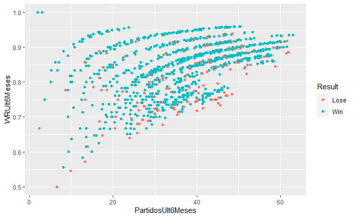

```r
df_matches %>%
  ggplot(aes(x = PartidosUlt6Meses, y = WRUlt6Meses,
             color = Result)) +
  geom_jitter(width = 1.5) #Cuando jugó muchos partidos y con alto wr hay mas chance de ganar
```

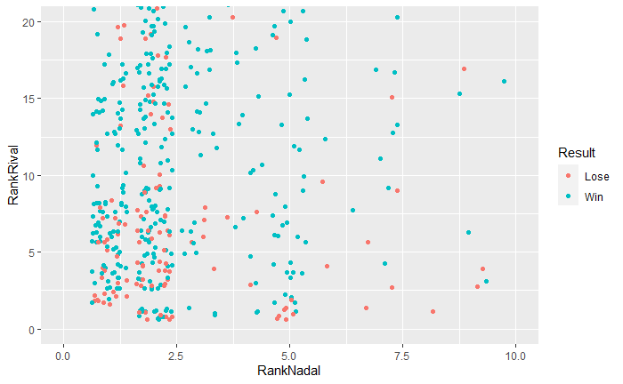

```r
df_matches %>%
  ggplot(aes(x = RankNadal, y = RankRival,
             color = Result)) +
  geom_jitter() +
  coord_cartesian(ylim = c(0, 20),
                  xlim = c(0, 10))
```

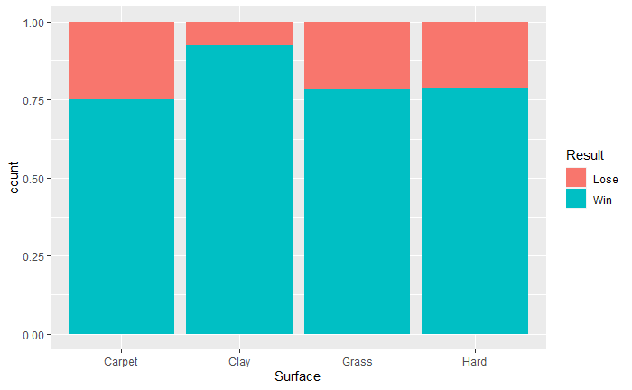

```r
df_matches %>%
  ggplot(aes(x = Surface, fill = Result)) +
  geom_bar(position = "fill")
```

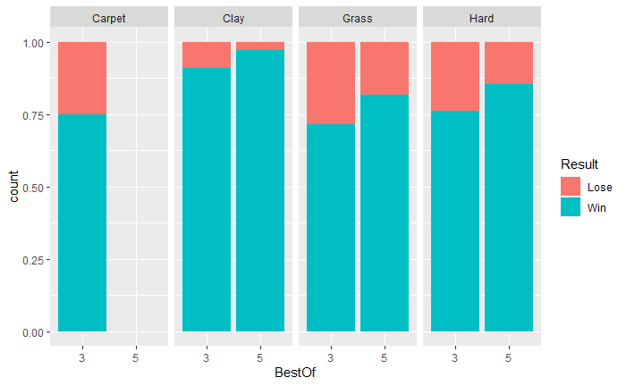

```r
df_matches %>%
  ggplot(aes(x = BestOf, fill = Result)) +
  geom_bar(position = "fill") +
  facet_grid(.~Surface)
```

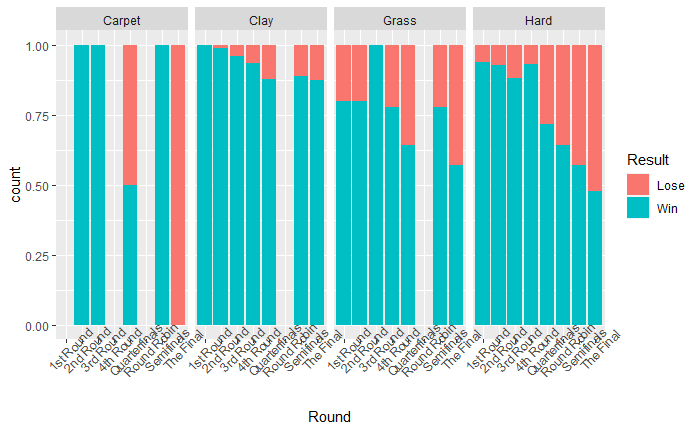

```r
df_matches %>%
  ggplot(aes(x = Round, fill = Result)) +
  geom_bar(position = "fill") +
  facet_grid(.~Surface) +
  theme(axis.text.x = element_text(angle = 45))
```

```r
glimpse(df_matches)
```

```
Rows: 1,073
Columns: 28
$ Location               <fct> Paris, Paris, Paris, Paris, Halle, London, London, Bastad, Bastad, Bastad, B~
$ Series                 <fct> Grand Slam, Grand Slam, Grand Slam, Grand Slam, International, Grand Slam, G~
$ Court                  <fct> Outdoor, Outdoor, Outdoor, Outdoor, Outdoor, Outdoor, Outdoor, Outdoor, Outd~
$ Surface                <fct> Clay, Clay, Clay, Clay, Grass, Grass, Grass, Clay, Clay, Clay, Clay, Clay, C~
$ Date                   <date> 2005-05-30, 2005-05-31, 2005-06-03, 2005-06-05, 2005-06-08, 2005-06-21, 200~
$ Round                  <fct> 4th Round, Quarterfinals, Semifinals, The Final, 1st Round, 1st Round, 2nd R~
$ BestOf                 <fct> 5, 5, 5, 5, 3, 5, 5, 3, 3, 3, 3, 3, 3, 3, 3, 3, 5, 3, 3, 3, 3, 3, 3, 3, 5, 5~
$ RankNadal              <dbl> 5, 5, 5, 5, 3, 3, 3, 3, 3, 3, 3, 3, 3, 3, 3, 3, 3, 2, 2, 2, 2, 2, 2, 2, 2, 2~
$ RankRival              <dbl> 24, 21, 1, 37, 147, 39, 69, 66, 50, 31, 20, 42, 167, 58, 57, 66, 13, 32, 56,~
$ PartidosUlt6Meses      <int> 51, 52, 53, 54, 55, 56, 57, 55, 56, 57, 58, 58, 57, 57, 58, 58, 59, 58, 59, ~
$ PartidosUlt3Meses      <int> 30, 31, 32, 33, 34, 35, 35, 30, 29, 30, 31, 31, 25, 25, 25, 25, 26, 21, 23, ~
$ PartidosUltMes         <int> 10, 11, 10, 9, 8, 9, 9, 4, 5, 5, 6, 7, 8, 8, 9, 9, 10, 6, 8, 8, 9, 11, 11, 1~
$ WRUlt6Meses            <dbl> 0.8823529, 0.8846154, 0.8867925, 0.8888889, 0.8727273, 0.8750000, 0.8596491,~
$ WRUlt3Meses            <dbl> 0.9333333, 0.9354839, 0.9375000, 0.9393939, 0.9117647, 0.9142857, 0.8857143,~
$ WRUltMes               <dbl> 1.0000000, 1.0000000, 1.0000000, 1.0000000, 0.8750000, 0.8888889, 0.7777778,~
$ PartidosRivalUlt6Meses <int> 23, 43, 49, 32, 3, 24, 23, 28, 37, 45, 35, 30, 5, 28, 27, 21, 48, 31, 22, 32~
$ PartidosRivalUlt3Meses <int> 17, 32, 28, 20, 3, 7, 14, 16, 18, 29, 22, 19, 4, 14, 14, 13, 24, 14, 10, 18,~
$ PartidosRivalUltMes    <int> 9, 11, 12, 11, 1, 3, 5, 2, 4, 9, 7, 10, 3, 6, 5, 6, 10, 8, 6, 6, 10, 8, 11, ~
$ WRRivalUlt6Meses       <dbl> 0.6086957, 0.6511628, 0.9387755, 0.7187500, 0.3333333, 0.5000000, 0.4347826,~
$ WRRivalUlt3Meses       <dbl> 0.6470588, 0.7500000, 0.9285714, 0.7500000, 0.3333333, 0.2857143, 0.5000000,~
$ WRRivalUltMes          <dbl> 0.6666667, 0.7272727, 0.9166667, 0.7272727, 1.0000000, 0.3333333, 0.6000000,~
$ SetsGanadosUltPartido  <dbl> 3, 3, 3, 3, 3, 1, 3, 1, 2, 2, 2, 2, 2, 2, 2, 2, 2, 3, 2, 2, 2, 2, 2, 2, 1, 3~
$ SetsPerdidosUltPartido <dbl> 0, 1, 0, 1, 1, 2, 0, 3, 0, 0, 0, 0, 1, 0, 0, 0, 0, 0, 1, 0, 0, 0, 0, 1, 2, 0~
$ ResultUltPartido       <chr> "Win", "Win", "Win", "Win", "Win", "Lose", "Win", "Lose", "Win", "Win", "Win~
$ RoundUltPartido        <chr> "3rd Round", "4th Round", "Quarterfinals", "Semifinals", "The Final", "1st R~
$ H2HPartidos            <int> 0, 2, 1, 1, 0, 0, 1, 0, 1, 2, 0, 0, 0, 2, 0, 0, 2, 0, 1, 1, 2, 0, 0, 1, 1, 0~
$ H2HGanados             <int> 0, 2, 0, 1, 0, 0, 1, 0, 1, 2, 0, 0, 0, 2, 0, 0, 1, 0, 1, 1, 2, 0, 0, 1, 1, 0~
$ Result                 <fct> Win, Win, Win, Win, Lose, Win, Lose, Win, Win, Win, Win, Win, Win, Win, Win,~
```